# Exploratory Data Analysis of Human Activity Recognition Data Set

## Motivation

The human activity data consists of 561 features. Using all of these features in a predictive modeling procedure can be computationally tedious. On the other hand, removing features can result in losing vital information that can describe the process that generated the dependent variables.

Instead of feature removal, trying to derive a new and reduced set of features from the existing set, can infact help us reduce computational efforts while maintaining informational integrity. This process is called feature extraction, with PCA being one of them.

## PCA Algorithm function

PCA is short for Principal Component Analysis. The original set of features are combined and linearly transformed into principal components. The set of principal components that explain the data effectively ,is chosen as the new feature set. The PCA process can be explained briefly in the following steps.

Let *X* be a matrix that represents the set of features that we are running PCA on. Each column in this matrix represents a feature.

- **Step 1** : Subtract each column by its mean and divide it by the standard deviation.
- **Step 2** : Let the new normalized matrix be *Z* . Using this normalized matrix , calculate the covariance matrix ie Z<sup>T</sup>Z . Let this covariance matrix be *C*
- **Step 3** : Decompose the covariance matrix into eigen values and eigen vectors. Here the `eigen()` function is used. The eigen vector corresponding to the highest eigen value is the direction of maximum variance.
- **Step 4** : To acquire the principal components, arrange the eigen values in descending order and reorder the eigen vectors accordingly. This reordering is taken care of by the `eigen()` function.
- **Step 5** : Now that we have the directions along which the variance is maximum, we need to project them on the data that we have ,to create the features. This is achieved by multiplying the scaled feature matrix *Z* with the reordered eigen matrix. The explained variance of each component is the eigen value corresponding to that component divided by the sum of eigen values.

These steps are encapsulated via the `pca_function()` that is defined below. This function returns the following

1. The projected vectors
2. The eigen values
3. The directions along which the data is projected.

```r
pca_function <- function(x,k){

  # x is the input data frame
  ## Step 1 Normalize each column

  x_scaled <- scale(x)
  ## Convert the data frame to a matrix

  x_mat <- as.matrix(x_scaled)

  ## Calculate the covariance matrix

  cov_x <- t(x_mat) %*% x_mat


  ## Eigen Value decomposition

  decomp_eigen <- eigen(cov_x)

  eigen_values <- decomp_eigen$values

  eigen_vectors <- decomp_eigen$vectors


  # choose top k eigen values and explain the variance

  eigen_values <- eigen_values[1:k]

  ## calculate the projected vectors


  projected_vectors <- x_mat %*% eigen_vectors
  projected_vectors <- projected_vectors[1:nrow(projected_vectors),1:k]
  return(list(projected_vectors=projected_vectors,eigen_values=eigen_values,basis_vectors=eigen_vectors))
}
```

## Choosing the Best K

Its good to visualize the optimal number of principal components by looking how well they explain the data. Consecutive principal components explain lesser and lesser of the variance.

```r
## removing the redundant columns




set.seed(42)

libraries_needed <- c('tidyr','dplyr','ggplot2','caret','purrr','rlang','caret')
lapply(libraries_needed ,require,character.only=TRUE)
```

```
## [[1]]
## [1] TRUE
##
## [[2]]
## [1] TRUE
##
## [[3]]
## [1] TRUE
##
## [[4]]
## [1] TRUE
##
## [[5]]
## [1] TRUE
##
## [[6]]
## [1] TRUE
##
## [[7]]
## [1] TRUE
```

```r
data_raw<- read.csv('train.csv',stringsAsFactors = FALSE)


data_raw_pca <- data_raw %>% select(-rn,-activity)




train_index <- sample(1:nrow(data_raw_pca),0.75*nrow(data_raw_pca))

data_raw_pca_train <- data_raw_pca[train_index,]

data_raw_pca_test <- data_raw_pca[-train_index,]

pca_decomposed_data <- pca_function(data_raw_pca_train,561)
```

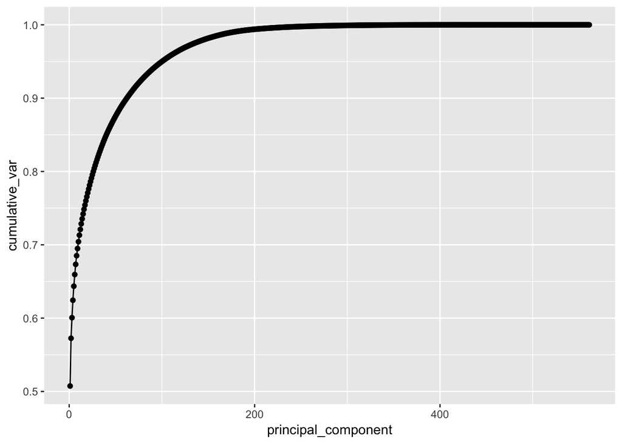

```r
## Convert to a data frame
options(scipen = 999)

eigen_values_and_vectors <- data.frame(principal_component = 1:ncol(data_raw_pca_train),eigen_values = pca_decomposed_data$eigen_values)


eigen_values_and_vectors %>%
  mutate(var = eigen_values/sum(eigen_values)) %>%
  mutate(cumulative_var = cumsum(var)) %>%
  ggplot(aes(x=principal_component,y=cumulative_var))+
  geom_line()+geom_point()
```

The first 100 principal components explain about 95% of the variance in the data. Let’s apply this transformation and choose the first 100 principal components. We will then use these principal components in our multinomial logistic regression model.

```r
pca_final_train <- pca_function(data_raw_pca_train,100)


data_pca_train <- as.data.frame(pca_final_train$projected_vectors)

data_pca_train$activity <- as.character(data_raw[train_index,]$activity)
```

Multinomial logistic regression models help in deriving the log odds of an event happening against a base event. This is example, the base event is chosen as `SITTING`.

```r
library(nnet)

data_pca_train$activity <- as.factor(data_pca_train$activity)
data_pca_train$activity <- relevel(data_pca_train$activity,ref='SITTING')

model_logistic_pca <- multinom(activity~.,data=data_pca_train)
#broom::tidy(model_logistic_pca)

test <- predict(model_logistic_pca,newdata=data_pca_train %>% select(-activity))


real_pred <- data.frame(real=data_pca_train$activity,test=as.character(test))
caret::confusionMatrix(real_pred$real,real_pred$test)
```

```
## Confusion Matrix and Statistics
##
##                     Reference
## Prediction           LAYING SITTING STANDING WALKING WALKING_DOWNSTAIRS
##   LAYING                530       0        0       0                  0
##   SITTING                 0     429       22       0                  0
##   STANDING                0      13      483       0                  0
##   WALKING                 0       0        0     457                  0
##   WALKING_DOWNSTAIRS      0       0        0       0                361
##   WALKING_UPSTAIRS        0       0        0       0                  1
##                     Reference
## Prediction           WALKING_UPSTAIRS
##   LAYING                            0
##   SITTING                           0
##   STANDING                          0
##   WALKING                           0
##   WALKING_DOWNSTAIRS                0
##   WALKING_UPSTAIRS                410
##
## Overall Statistics
##
##                Accuracy : 0.9867
##                  95% CI : (0.9816, 0.9907)
##     No Information Rate : 0.1959
##     P-Value [Acc > NIR] : < 0.00000000000000022
##
##                   Kappa : 0.984
##
##  Mcnemar's Test P-Value : NA
##
## Statistics by Class:
##
##                      Class: LAYING Class: SITTING Class: STANDING
## Sensitivity                 1.0000         0.9706          0.9564
## Specificity                 1.0000         0.9903          0.9941
## Pos Pred Value              1.0000         0.9512          0.9738
## Neg Pred Value              1.0000         0.9942          0.9900
## Prevalence                  0.1959         0.1633          0.1866
## Detection Rate              0.1959         0.1585          0.1785
## Detection Prevalence        0.1959         0.1667          0.1833
## Balanced Accuracy           1.0000         0.9804          0.9753
##                      Class: WALKING Class: WALKING_DOWNSTAIRS
## Sensitivity                  1.0000                    0.9972
## Specificity                  1.0000                    1.0000
## Pos Pred Value               1.0000                    1.0000
## Neg Pred Value               1.0000                    0.9996
## Prevalence                   0.1689                    0.1338
## Detection Rate               0.1689                    0.1334
## Detection Prevalence         0.1689                    0.1334
## Balanced Accuracy            1.0000                    0.9986
##                      Class: WALKING_UPSTAIRS
## Sensitivity                           1.0000
## Specificity                           0.9996
## Pos Pred Value                        0.9976
## Neg Pred Value                        1.0000
## Prevalence                            0.1515
## Detection Rate                        0.1515
## Detection Prevalence                  0.1519
## Balanced Accuracy                     0.9998
```

- As per the output, the 98% of the data points were classified properly.
- For the purpose of prediction on the test data, we project the scaled test data onto the principal directions.
- The resulting vectors are then used in the model to generate the predicted values.
- These predicted values are then compared against the test values to evaluate the test accuracy,

## Testing

```r
## testing

## Project scaled test data onto the directons of maximum variance (basis vectors)
data_pca_test <- as.matrix(scale(data_raw_pca_test)) %*% pca_final_train$basis_vectors

data_pca_test <- as.data.frame(data_pca_test)

data_pca_test <- data_pca_test[,1:100]

data_pca_test$activity <- data_raw[-train_index,]$activity

test_prediction <- predict(model_logistic_pca,newdata = data_pca_test %>% select(-activity))
real_pred_test <- data.frame(real=data_pca_test$activity,test=as.character(test_prediction))


caret::confusionMatrix(real_pred_test$real,real_pred_test$test)
```

```
## Confusion Matrix and Statistics
##
##                     Reference
## Prediction           LAYING SITTING STANDING WALKING WALKING_DOWNSTAIRS
##   LAYING                150       1        0       0                  0
##   SITTING                 1     159       11       0                  0
##   STANDING                0      19      153       0                  0
##   WALKING                 0       0        1     143                  0
##   WALKING_DOWNSTAIRS      0       1        2       1                125
##   WALKING_UPSTAIRS        1       2        0       1                  3
##                     Reference
## Prediction           WALKING_UPSTAIRS
##   LAYING                            0
##   SITTING                           1
##   STANDING                          0
##   WALKING                           2
##   WALKING_DOWNSTAIRS                3
##   WALKING_UPSTAIRS                123
##
## Overall Statistics
##
##                Accuracy : 0.9446
##                  95% CI : (0.9276, 0.9586)
##     No Information Rate : 0.2016
##     P-Value [Acc > NIR] : < 0.00000000000000022
##
##                   Kappa : 0.9334
##
##  Mcnemar's Test P-Value : NA
##
## Statistics by Class:
##
##                      Class: LAYING Class: SITTING Class: STANDING
## Sensitivity                 0.9868         0.8736          0.9162
## Specificity                 0.9987         0.9820          0.9742
## Pos Pred Value              0.9934         0.9244          0.8895
## Neg Pred Value              0.9973         0.9685          0.9808
## Prevalence                  0.1683         0.2016          0.1849
## Detection Rate              0.1661         0.1761          0.1694
## Detection Prevalence        0.1672         0.1905          0.1905
## Balanced Accuracy           0.9928         0.9278          0.9452
##                      Class: WALKING Class: WALKING_DOWNSTAIRS
## Sensitivity                  0.9862                    0.9766
## Specificity                  0.9960                    0.9910
## Pos Pred Value               0.9795                    0.9470
## Neg Pred Value               0.9974                    0.9961
## Prevalence                   0.1606                    0.1417
## Detection Rate               0.1584                    0.1384
## Detection Prevalence         0.1617                    0.1462
## Balanced Accuracy            0.9911                    0.9838
##                      Class: WALKING_UPSTAIRS
## Sensitivity                           0.9535
## Specificity                           0.9910
## Pos Pred Value                        0.9462
## Neg Pred Value                        0.9922
## Prevalence                            0.1429
## Detection Rate                        0.1362
## Detection Prevalence                  0.1440
## Balanced Accuracy                     0.9722
```

- 94% of test data is correctly predicted.

## 10 folds Cross validation of the approach

Good training and test accuracies are achieved in the previous sections with one set of test and train data. A good way to make sure that the predictive modeling approach is robust is to run it with different combinations of test and train data.

```r
random_data <- dplyr::slice(data_raw,sample(1:n()))
test_idx <- round(seq(1,nrow(data_raw),by=nrow(data_raw)/11))
accuracy_df <- data.frame(iteration= as.numeric(),training_score= as.numeric(),testing_score= as.numeric())
for(i in 1:10){


  ## Training

  test_data <- slice(random_data,test_idx[i]:test_idx[i+1])
  train_data <- slice(random_data,-test_idx[i]:-test_idx[i+1])
  pca_final_train <- pca_function(train_data %>% select(-rn,-activity),100)

  data_pca_train <- as.data.frame(pca_final_train$projected_vectors)
  data_pca_train$activity <- as.character(train_data$activity)
  #data_pca_train$activity <- relevel(data_pca_train$activity,ref='SITTING')

  model_cv <- multinom(activity~.,data=data_pca_train)

  train_predict <- as.character(predict(model_cv,newdata=data_pca_train %>% select(-activity)))

  training_score <- sum(as.character(train_predict)==as.character(train_data$activity))/nrow(train_data)





  ## Testing
  data_pca_test <- as.matrix(scale(test_data %>% select(-rn,-activity))) %*% pca_final_train$basis_vectors

  data_pca_test <- as.data.frame(data_pca_test)

  data_pca_test <- data_pca_test[,1:100]

  data_pca_test$activity <- test_data$activity



  predict_cv <- as.character(predict(model_cv,newdata=data_pca_test %>% select(-activity)))
  testing_score <- sum(as.character(predict_cv)==as.character(test_data$activity))/nrow(test_data)
  accuracy_df <- rbind(accuracy_df,data.frame(iteration=i,testing_score=testing_score,training_score =training_score ))








}
```

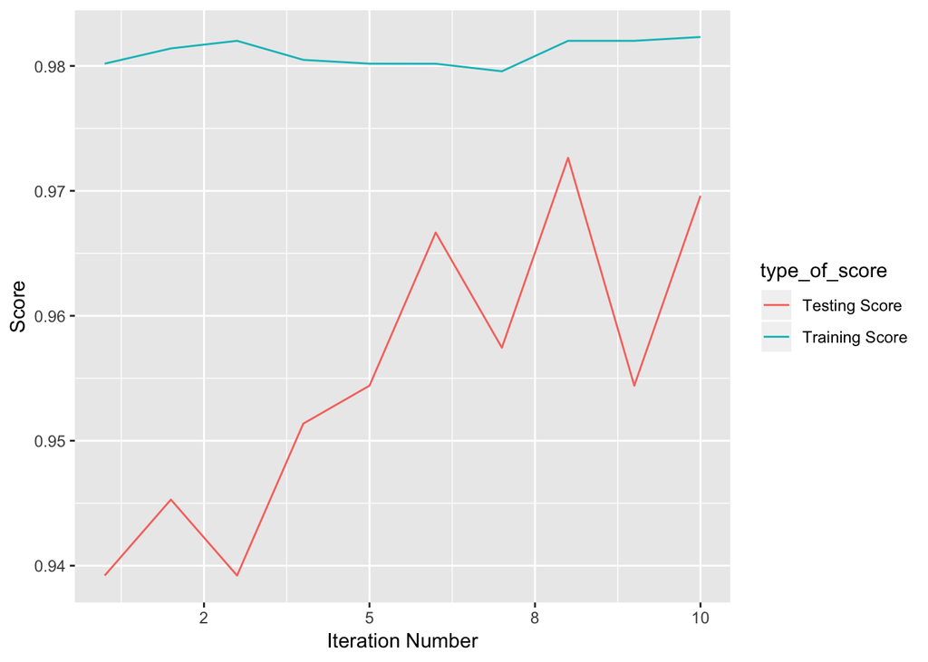

```r
scaleFUN <- function(x) sprintf("%.f", x)

accuracy_df %>%
  tidyr::gather(type_of_score,value,2:3) %>%
  mutate(type_of_score = ifelse(grepl('training',type_of_score),'Training Score','Testing Score')) %>%
  ggplot(aes(x=iteration,y=value,color=type_of_score))+geom_line()+
  scale_x_continuous(labels = scaleFUN)+
  labs(x='Iteration Number',y='Score')
```

- Training scores are stable and testing scores range from 0.94 to 0.97 which is acceptable for a good multi class classifier.